# GSP genotyping primers for UniformMu *mu1046085* in *Zm00004b034131* (W22)

Reproducible pipeline — R + system() calls; gggenomes annotation map

Author

thegemmalab@ncsu.edu

Published

June 18, 2026

```r
suppressPackageStartupMessages({
  library(gggenomes); library(ggplot2); library(readr)
  library(dplyr); library(stringr); library(Biostrings)
})

# Paths are relative to the project root — Quarto executes chunks from there (portable; no absolute paths).
DATA      <- "data"; WORK <- "work"; RES <- "results"
for (d in c(DATA, WORK, RES)) dir.create(d, showWarnings = FALSE, recursive = TRUE)

BASE   <- "https://download.maizegdb.org/Zm-W22-REFERENCE-NRGENE-2.0"
GENOME <- file.path(DATA, "Zm-W22-REFERENCE-NRGENE-2.0.fa.gz")
GFFGZ  <- file.path(DATA, "Zm-W22-REFERENCE-NRGENE-2.0_Zm00004b.1.gff3.gz")
GENE   <- "Zm00004b034131"

# Insertion (UniformMu mu1046085, stock UFMu-05701); 9-bp TSD; W22 NRGENE 2.0
TSD_SEQ <- "GTTGCGCTG"
TIR6    <- "AGAGAAGCCAACGCCAWCGCCTCYATTTCGTC"   # Mu-TIR primer (Tm 71.7); TIR8 = fallback
PAD     <- 2000L                                  # gene +/- 2 kb window

sh <- function(cmd) system2("bash", c("-c", shQuote(cmd)), stdout = TRUE, stderr = TRUE)
```

## 1. Tools

```r
tools <- c("curl","samtools","primer3_core","e-PCR")
data.frame(tool = tools,
           path = vapply(tools, function(t) { p <- Sys.which(t); if (p=="") "MISSING" else p }, ""))
```

```
                     tool                                    path
curl                 curl                           /usr/bin/curl
samtools         samtools              /opt/homebrew/bin/samtools
primer3_core primer3_core /Users/fvrodriguez/bio/bin/primer3_core
e-PCR               e-PCR        /Users/fvrodriguez/bio/bin/e-PCR
```

## 2. W22 reference (download guarded — skipped if present)

```r
if (!file.exists(GENOME)) sh(sprintf("curl -sL --retry 3 -o %s %s/%s", shQuote(GENOME), BASE, basename(GENOME)))
if (!file.exists(paste0(GENOME, ".fai"))) sh(sprintf("samtools faidx %s", shQuote(GENOME)))   # builds .fai + .gzi
if (!file.exists(GFFGZ)) sh(sprintf("curl -sL -o %s %s/%s", shQuote(GFFGZ), BASE, basename(GFFGZ)))
file.exists(c(GENOME, paste0(GENOME, ".fai"), GFFGZ))
```

```
[1] TRUE TRUE TRUE
```

## 3. Gene model

```r
genegff <- file.path(WORK, "gene.gff3")
if (!file.exists(genegff)) sh(sprintf("gzip -dc %s | grep %s > %s", shQuote(GFFGZ), GENE, shQuote(genegff)))
gff <- read_tsv(genegff, col_names = c("seqid","src","type","start","end","score","strand","phase","attr"),
                show_col_types = FALSE)
gene_row <- gff %>% filter(type == "gene")
CHR <- gene_row$seqid; STRAND <- gene_row$strand
GENE_START <- gene_row$start; GENE_END <- gene_row$end
exons <- gff %>% filter(type == "exon", str_detect(attr, "_T001")) %>% arrange(desc(start))
EXON1_END <- max(exons$end)   # = gene 5' end (minus strand)
cat(sprintf("%s  %s:%d-%d  strand %s  | %d exons\n", GENE, CHR, GENE_START, GENE_END, STRAND, nrow(exons)))
```

```
Zm00004b034131  chr9:150178549-150184207  strand -  | 4 exons
```

```r
knitr::kable(exons %>% transmute(feature=type, start, end), caption = "Exons (T001)")
```

Exons (T001)

| feature | start | end |
| --- | --- | --- |
| exon | 150183805 | 150184207 |
| exon | 150181691 | 150181980 |
| exon | 150179879 | 150180169 |
| exon | 150178549 | 150179052 |

## 4. Extract locus (gene ± 2 kb) and locate the 9-bp TSD

```r
WIN_START <- GENE_START - PAD; WIN_END <- GENE_END + PAD
locus_fa  <- file.path(WORK, "locus.fa")
if (!file.exists(locus_fa))
  sh(sprintf("samtools faidx %s %s:%d-%d > %s", shQuote(GENOME), CHR, WIN_START, WIN_END, shQuote(locus_fa)))
locus <- as.character(readDNAStringSet(locus_fa)[[1]])

hits <- matchPattern(TSD_SEQ, DNAString(locus))
stopifnot(length(hits) == 1)                     # unique site in the window
TSD_LOCAL <- start(hits)[1]                       # 1-based local
TSD_G     <- WIN_START + TSD_LOCAL - 1            # genomic 1-based start of TSD
TSD_LEN   <- nchar(TSD_SEQ)
cat(sprintf("TSD %s unique at %s:%d-%d (W22)\n", TSD_SEQ, CHR, TSD_G, TSD_G + TSD_LEN - 1))
```

```
TSD GTTGCGCTG unique at chr9:150183971-150183979 (W22)
```

```r
loc <- function(g) g - WIN_START + 1L             # genomic -> window-local 1-based
```

## 5. Primer3 design — 3 forward + 3 reverse GSPs

One single-sided Primer3 run per flank (forward = exon-side, reverse = below the insertion), each GSP kept ≥ 80 bp off the TSD so junction bands are gel-resolvable; all F×R WT products < 500 bp.

```r
off <- TSD_G - WIN_START                          # 0-based index of TSD start
MIN_OFF <- 80L
COMMON <- c("PRIMER_TASK=generic","PRIMER_PICK_INTERNAL_OLIGO=0","PRIMER_FIRST_BASE_INDEX=0",
  "PRIMER_MIN_SIZE=21","PRIMER_OPT_SIZE=24","PRIMER_MAX_SIZE=27",
  "PRIMER_MIN_TM=60.0","PRIMER_OPT_TM=62.0","PRIMER_MAX_TM=65.0",
  "PRIMER_MIN_GC=40.0","PRIMER_OPT_GC_PERCENT=50.0","PRIMER_MAX_GC=60.0",
  "PRIMER_GC_CLAMP=1","PRIMER_MAX_POLY_X=4","PRIMER_MAX_NS_ACCEPTED=0",
  "PRIMER_THERMODYNAMIC_OLIGO_ALIGNMENT=0","PRIMER_THERMODYNAMIC_TEMPLATE_ALIGNMENT=0",
  "PRIMER_EXPLAIN_FLAG=1","PRIMER_NUM_RETURN=40")

parse_p3 <- function(path) {
  L <- readLines(path); L <- L[grepl("=", L, fixed = TRUE) & L != "="]
  kv <- strsplit(L, "=", fixed = TRUE)
  setNames(vapply(kv, function(x) paste(x[-1], collapse = "="), ""), vapply(kv, `[`, "", 1))
}

run_pool <- function(side) {
  if (side == "F") {                              # gene-forward = RIGHT primer, in exon1 above insertion
    incl_start <- (off + TSD_LEN - 1) + MIN_OFF
    incl_len   <- (EXON1_END - WIN_START) - incl_start + 1
    pick <- c("PRIMER_PICK_LEFT_PRIMER=0","PRIMER_PICK_RIGHT_PRIMER=1"); tag <- "RIGHT"
  } else {                                        # gene-reverse = LEFT primer, below insertion
    incl_start <- off - 245
    incl_len   <- (off - MIN_OFF) - incl_start
    pick <- c("PRIMER_PICK_LEFT_PRIMER=1","PRIMER_PICK_RIGHT_PRIMER=0"); tag <- "LEFT"
  }
  inp <- file.path(WORK, sprintf("p3_%s.txt", side)); outp <- file.path(WORK, sprintf("p3_%s_out.txt", side))
  writeLines(c(sprintf("SEQUENCE_ID=mu1046085_%s", side), sprintf("SEQUENCE_TEMPLATE=%s", locus),
               sprintf("SEQUENCE_INCLUDED_REGION=%d,%d", incl_start, incl_len), pick, COMMON, "="), inp)
  sh(sprintf("primer3_core %s > %s", shQuote(inp), shQuote(outp)))
  d <- parse_p3(outp); n <- as.integer(d[[sprintf("PRIMER_%s_NUM_RETURNED", tag)]])
  if (is.na(n) || n == 0) return(data.frame())
  do.call(rbind, lapply(0:(n-1), function(i) {
    pos <- as.integer(strsplit(d[[sprintf("PRIMER_%s_%d", tag, i)]], ",")[[1]])
    data.frame(name = NA, side = side, rank = i,
      seq = d[[sprintf("PRIMER_%s_%d_SEQUENCE", tag, i)]],
      len = pos[2], tm = as.numeric(d[[sprintf("PRIMER_%s_%d_TM", tag, i)]]),
      gc  = as.numeric(d[[sprintf("PRIMER_%s_%d_GC_PERCENT", tag, i)]]),
      g5  = WIN_START + pos[1], stringsAsFactors = FALSE)
  }))
}

select_spaced <- function(cand, n = 3, min_gap = 22) {
  cand <- cand[order(cand$rank), ]; keep <- integer(0)
  for (i in seq_len(nrow(cand)))
    if (all(abs(cand$g5[i] - cand$g5[keep]) >= min_gap)) { keep <- c(keep, i); if (length(keep) == n) break }
  cand[keep, ]
}

region_of <- function(g) ifelse(g >= EXON1_END - (EXON1_END - max(exons$start[exons$start>=GENE_START & exons$end<=EXON1_END])) , "exon1",
                          ifelse(g > GENE_END, "promoter", ifelse(g < GENE_START, "3'flank", "intron/exon")))
in_exon <- function(g) any(g >= exons$start & g <= exons$end)

F <- select_spaced(run_pool("F")); F <- F[order(-F$g5), ]; F$name <- paste0("GSP-F", 1:3)
R <- select_spaced(run_pool("R")); R <- R[order( R$g5), ]; R$name <- paste0("GSP-R", 1:3)
gsp <- rbind(F, R)
gsp$region   <- ifelse(vapply(gsp$g5, in_exon, TRUE), "exon", "intron")
gsp$dist_ins <- ifelse(gsp$side == "F", gsp$g5 - (TSD_G + TSD_LEN - 1), TSD_G - gsp$g5)
gsp$TIR6_jct <- gsp$dist_ins + TSD_LEN + nchar(TIR6)
write_tsv(gsp[, c("name","side","seq","len","tm","gc","g5","region","dist_ins","TIR6_jct")],
          file.path(RES, "gsp_table.tsv"))
knitr::kable(gsp %>% transmute(name, sequence=seq, len, Tm=round(tm,1), `GC%`=round(gc),
             `5'_chr9`=g5, region, dist_to_insertion=dist_ins),
             caption = sprintf("GSPs (Tm spread %.2f C). Fixed partner: TIR6 (Tm 71.7), TIR8 fallback.",
                               max(gsp$tm)-min(gsp$tm)))
```

GSPs (Tm spread 1.35 C). Fixed partner: TIR6 (Tm 71.7), TIR8 fallback.

|  | name | sequence | len | Tm | GC% | 5’_chr9 | region | dist_to_insertion |
| --- | --- | --- | --- | --- | --- | --- | --- | --- |
| 3 | GSP-F1 | GACTATACCGACTACCAGCTGCAC | 24 | 62.6 | 54 | 150184198 | exon | 219 |
| 4 | GSP-F2 | CGGGCGAGATAATATCGTGACATC | 24 | 61.3 | 50 | 150184175 | exon | 196 |
| 1 | GSP-F3 | GGGTATCTCTTTCTCCGGGTAGTG | 24 | 61.8 | 54 | 150184137 | exon | 158 |
| 11 | GSP-R1 | ACTAAGTTGTCTAGGAGCTCCACTG | 25 | 61.6 | 48 | 150183730 | intron | 241 |
| 13 | GSP-R2 | GAGAGCAGTGCTAACTAAAAGGGC | 24 | 61.7 | 50 | 150183761 | intron | 210 |
| 12 | GSP-R3 | GTAATGTCAGGCGTACCAGGAGG | 23 | 62.6 | 57 | 150183789 | intron | 182 |

## 6. Amplicon table

```r
pos <- function(nm) gsp$g5[gsp$name == nm]
wt_pairs <- list(c("GSP-F3","GSP-R2"), c("GSP-F2","GSP-R1"), c("GSP-F1","GSP-R3"))
wt <- do.call(rbind, lapply(wt_pairs, function(p) data.frame(
  primer_pair = paste(p[1], "+", p[2]), amplicon = "WT control", template = "no-insertion allele",
  size_bp = as.character(abs(pos(p[1]) - pos(p[2])) + 1), precision = "exact")))
jct <- rbind(
  do.call(rbind, lapply(F$name, function(n) data.frame(primer_pair = paste(n, "+ TIR6"),
    amplicon = "5' junction", template = "Mu allele",
    size_bp = paste0("~", gsp$TIR6_jct[gsp$name==n]), precision = "approx"))),
  do.call(rbind, lapply(R$name, function(n) data.frame(primer_pair = paste(n, "+ TIR6"),
    amplicon = "3' junction", template = "Mu allele",
    size_bp = paste0("~", gsp$TIR6_jct[gsp$name==n]), precision = "approx"))))
amp_tab <- rbind(wt, jct); write_tsv(amp_tab, file.path(RES, "amplicons.tsv"))
knitr::kable(amp_tab, caption = "Diagnostic amplicons (WT sizes exact; junctions +constant intra-TIR offset).")
```

Diagnostic amplicons (WT sizes exact; junctions +constant intra-TIR offset).

| primer_pair | amplicon | template | size_bp | precision |
| --- | --- | --- | --- | --- |
| GSP-F3 + GSP-R2 | WT control | no-insertion allele | 377 | exact |
| GSP-F2 + GSP-R1 | WT control | no-insertion allele | 446 | exact |
| GSP-F1 + GSP-R3 | WT control | no-insertion allele | 410 | exact |
| GSP-F1 + TIR6 | 5’ junction | Mu allele | ~260 | approx |
| GSP-F2 + TIR6 | 5’ junction | Mu allele | ~237 | approx |
| GSP-F3 + TIR6 | 5’ junction | Mu allele | ~199 | approx |
| GSP-R1 + TIR6 | 3’ junction | Mu allele | ~282 | approx |
| GSP-R2 + TIR6 | 3’ junction | Mu allele | ~251 | approx |
| GSP-R3 + TIR6 | 3’ junction | Mu allele | ~223 | approx |

## 7. Specificity — forward e-PCR over the whole W22 genome

```r
W22FA <- file.path(DATA, "W22.fa")
if (!file.exists(W22FA)) sh(sprintf("bgzip -dc %s > %s", shQuote(GENOME), shQuote(W22FA)))
sts <- file.path(WORK, "epcr_sts.txt")
combos <- expand.grid(Fi = 1:3, Rj = 1:3)
writeLines(apply(combos, 1, function(x) sprintf("F%dxR%d\t%s\t%s\t100-600",
  x["Fi"], x["Rj"], F$seq[x["Fi"]], R$seq[x["Rj"]])), sts)
epcr_out <- file.path(RES, "epcr_fwd.txt")
# Specificity params: allow up to 3 mismatches (-n 3) + 1 gap (-g 1) per primer -> relaxed
# off-target scan. -a f = precise-alignment fallback, recommended by e-PCR whenever gaps > 0.
epcr_cmd <- sprintf("e-PCR -n 3 -g 1 -m 200 -w 7 -t 3 -a f -o %s %s %s",
                    shQuote(epcr_out), shQuote(sts), shQuote(W22FA))
cat(epcr_cmd, "\n")            # show the exact command line in the rendered report
```

```
e-PCR -n 3 -g 1 -m 200 -w 7 -t 3 -a f -o 'results/epcr_fwd.txt' 'work/epcr_sts.txt' 'data/W22.fa'
```

```r
sh(epcr_cmd)
```

```
character(0)
```

```r
ep <- read_tsv(epcr_out, comment = "#", col_names =
  c("seq","sts","strand","from","to","size","mism","gaps","x"), show_col_types = FALSE)
cat(sprintf("e-PCR: %d combos, %d total amplicons, %d distinct loci (all on %s) -> %s\n",
    nrow(combos), nrow(ep), length(unique(paste(ep$seq, ep$from))), unique(ep$seq),
    ifelse(all(table(ep$sts) == 1), "every pair single-product = SPECIFIC", "CHECK")))
```

```
e-PCR: 9 combos, 9 total amplicons, 3 distinct loci (all on chr9) -> every pair single-product = SPECIFIC
```

```r
knitr::kable(ep %>% transmute(pair=sts, chr=seq, from, to, size_bp=str_replace(size,"/.*","")),
             caption = "Forward e-PCR hits (relaxed scan: up to 3 mismatches, 1 gap).")
```

Forward e-PCR hits (relaxed scan: up to 3 mismatches, 1 gap).

| pair | chr | from | to | size_bp |
| --- | --- | --- | --- | --- |
| F1xR1 | chr9 | 150183730 | 150184197 | 468 |
| F2xR1 | chr9 | 150183730 | 150184174 | 445 |
| F3xR1 | chr9 | 150183730 | 150184136 | 407 |
| F1xR2 | chr9 | 150183761 | 150184197 | 437 |
| F2xR2 | chr9 | 150183761 | 150184174 | 414 |
| F3xR2 | chr9 | 150183761 | 150184136 | 376 |
| F1xR3 | chr9 | 150183789 | 150184197 | 409 |
| F2xR3 | chr9 | 150183789 | 150184174 | 386 |
| F3xR3 | chr9 | 150183789 | 150184136 | 348 |

## 8. Annotation map (gggenomes — LH244_CRISPR style)

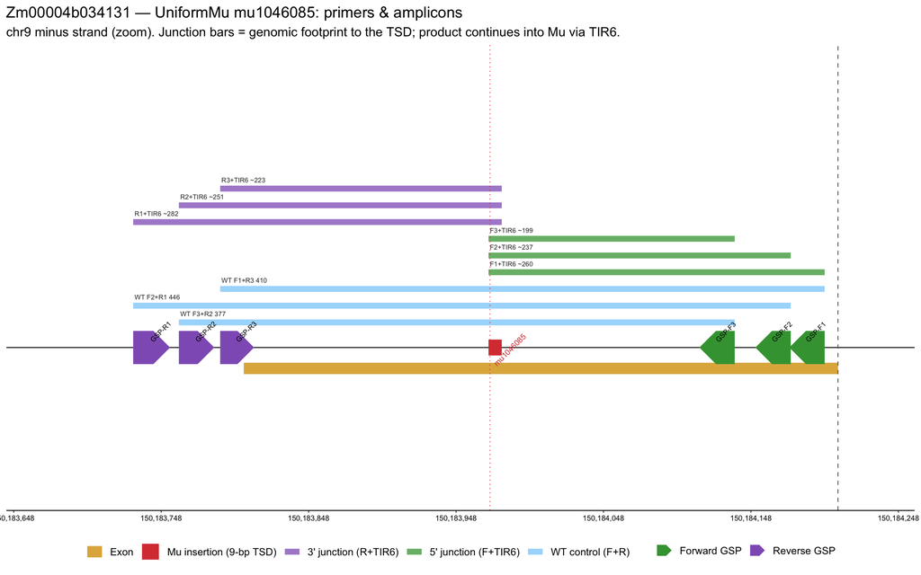

```r
seqs <- data.frame(seq_id = "locus", length = nchar(locus))
exon_df <- exons %>% transmute(seq_id = "locus", start = loc(start), end = loc(end), feat_type = "Exon")
ins_df  <- data.frame(seq_id = "locus", start = loc(TSD_G), end = loc(TSD_G+TSD_LEN-1),
                      feat_type = "Insertion", name = "mu1046085")
prim <- do.call(rbind, lapply(seq_len(nrow(gsp)), function(i) { r <- gsp[i, ]
  if (r$side == "F") { s5 <- r$g5; s3 <- r$g5 - (r$len-1); ft <- "forward_primer" }
  else               { s5 <- r$g5; s3 <- r$g5 + (r$len-1); ft <- "reverse_primer" }
  data.frame(seq_id="locus", start=loc(s5), end=loc(s3), feat_type=ft, name=r$name) }))
mkamp <- function(nm, a, b, ft) data.frame(seq_id="locus", start=loc(min(a,b)), end=loc(max(a,b)),
                                           feat_type=ft, name=nm)
amp <- do.call(rbind, c(
  lapply(wt_pairs, function(p) mkamp(sprintf("WT %s+%s %d", sub("GSP-","",p[1]), sub("GSP-","",p[2]),
         abs(pos(p[1])-pos(p[2]))+1), pos(p[1]), pos(p[2]), "WT_amplicon")),
  lapply(F$name, function(n) mkamp(sprintf("%s+TIR6 ~%d", sub("GSP-","",n), gsp$TIR6_jct[gsp$name==n]),
         pos(n), TSD_G, "junction_5")),
  lapply(R$name, function(n) mkamp(sprintf("%s+TIR6 ~%d", sub("GSP-","",n), gsp$TIR6_jct[gsp$name==n]),
         pos(n), TSD_G+TSD_LEN-1, "junction_3"))))
amp$yoff <- 0.18 + 0.12 * (seq_len(nrow(amp)) - 1)

p <- gggenomes(seqs = seqs, genes = prim,
               feats = list(amplicons = amp, exons = exon_df, insertion = ins_df)) +
  geom_seq() +
  geom_feat(data = feats(exons), aes(y = y-0.15, yend = y-0.15, color = feat_type),
            position="identity", linewidth = 5, alpha = 0.85) +
  geom_feat(data = feats(insertion), aes(color = feat_type), linewidth = 7) +
  geom_feat_label(data = feats(insertion), aes(label = name), size = 2.6, nudge_y = -0.12, color = "#D94040") +
  geom_feat(data = feats(amplicons), aes(y = y+yoff, yend = y+yoff, color = feat_type),
            position="identity", linewidth = 2.6, alpha = 0.75) +
  geom_text(data = amp, aes(x = pmin(start,end), y = 1+yoff+0.045, label = name),
            hjust = 0, vjust = 0, size = 2.2, color = "grey20", inherit.aes = FALSE) +
  geom_gene(aes(fill = feat_type), color = NA, size = 11) +
  geom_gene_label(aes(label = name), size = 2.3, nudge_y = 0.05) +
  geom_vline(xintercept = c(loc(GENE_START), loc(GENE_END)), linetype = "dashed",
             color = "grey40", linewidth = 0.4) +
  geom_vline(xintercept = loc(TSD_G), linetype = "dotted", color = "#D94040", linewidth = 0.3) +
  scale_color_manual(name = NULL,
    values = c("Exon"="#DAA520","Insertion"="#D94040","WT_amplicon"="lightskyblue",
               "junction_5"="#40A040","junction_3"="#9060C0"),
    labels = c("Exon"="Exon","Insertion"="Mu insertion (9-bp TSD)","WT_amplicon"="WT control (F+R)",
               "junction_5"="5' junction (F+TIR6)","junction_3"="3' junction (R+TIR6)")) +
  scale_fill_manual(name = NULL, values = c("forward_primer"="#40A040","reverse_primer"="#9060C0"),
    labels = c("forward_primer"="Forward GSP","reverse_primer"="Reverse GSP")) +
  scale_x_continuous(labels = function(x) format(round(x + WIN_START - 1), big.mark = ",")) +
  coord_cartesian(xlim = c(loc(TSD_G-300), loc(TSD_G+260)), ylim = c(0.55, 2.45)) +
  labs(title = sprintf("%s — UniformMu mu1046085: primers & amplicons", GENE),
       subtitle = "chr9 minus strand (zoom). Junction bars = genomic footprint to the TSD; product continues into Mu via TIR6.",
       x = "chr9 position (bp)") +
  theme(legend.position = "bottom", axis.text.y = element_blank(), axis.ticks.y = element_blank(),
        axis.title.y = element_blank(), panel.grid.minor = element_blank())
ggsave(file.path(RES, "annotation_map.png"), p, width = 12, height = 7.5, dpi = 150)
p
```

## 9. Assay & interpretation

Multiplex per plant: **GSP-F + GSP-R + TIR6**.

- **WT band only** (377 / 410 / 446 bp) → homozygous wild-type
- **Junction band(s) only** (GSP + TIR6, ~199–282 bp) → homozygous insertion
- **Both** → heterozygous

Workflow (McCarty/UniformMu): confirm each GSP-F+GSP-R pair on **W22 control DNA**; then run **both** GSP-F+TIR6 and GSP-R+TIR6 on UFMu plant DNA (occasionally only one side amplifies); **sequence** junction products (TSD `GTTGCGCTG` abutting the TIR). e-PCR shows the locus is single-copy → no false-heterozygous-from-duplication risk.

**Touchdown PCR:** 94 °C 1′; [94 °C 25″ / 62 °C 30″ / 72 °C 1′] ×8–10; [94 °C 25″ / 56 °C 30″ / 72 °C 1′] ×~27; 72 °C 5′; 4 °C. Add **5 % DMSO** (fresh) or PCRx Enhancer for GC-rich maize template. TIR6’s high Tm (71.7) vs ~62 °C GSPs is handled by the touchdown.

## References

- **UniformMu PCR confirmation protocol** (TIR6/TIR8 primers, touchdown PCR, genotyping workflow): *UniformMu Resource (2011)*, McCarty lab. https://download.maizegdb.org/Insertions/UniformMu/UniformMu_Resource_2011.pdf
- Settles AM *et al.* (2004) Sequence-indexed mutations in maize using the UniformMu transposon-tagging population. *BMC Genomics* 5:84.
- W22 reference genome: **Zm-W22-REFERENCE-NRGENE-2.0**, MaizeGDB. https://download.maizegdb.org/Zm-W22-REFERENCE-NRGENE-2.0/
- Tools: Primer3, NCBI e-PCR/re-PCR, samtools, gggenomes (Hackl *et al.*).